# Introduction to the Tidyverse

Lessons from DataCamp

Neil Yetz

# Introduction

The following documentoutlines the written portion of the lessons from [DataCamp](https://www.datacamp.com/)’s [Introduction to the Tidyverse](https://www.datacamp.com/courses/introduction-to-the-tidyverse). This works to develop skills within the [tidyverse](https://www.tidyverse.org) package.

As a note: All text is completely copied and pasted from the course. There are instances where the document refers to the “editor on the right”, please note, that in this notebook document all of these instances are noted in the “r-chunks” (areas containing working r-code), which occurs below the text, rather than to the right. Furthermore, This lesson contained instructional videos at the begining of new concepts that are not detailed in this document. However, even without these videos, the instructions are quite clear in indicating what the code is accomplishing.

This document was created by Neil Yetz on 05/17/2018. Please send any questions or concerns in this document to Neil at ndyetz@gmail.com

# Course Description

This is an introduction to the programming language R, focused on a powerful set of tools known as the “tidyverse”. In the course you’ll learn the intertwined processes of data manipulation and visualization through the tools dplyr and ggplot2. You’ll learn to manipulate data by filtering, sorting and summarizing a real dataset of historical country data in order to answer exploratory questions. You’ll then learn to turn this processed data into informative line plots, bar plots, histograms, and more with the ggplot2 package. This gives a taste both of the value of exploratory data analysis and the power of tidyverse tools. This is a suitable introduction for people who have no previous experience in R and are interested in learning to perform data analysis.

# Chapter 1: Data wrangling

In this chapter, you’ll learn to do three things with a table: filter for particular observations, arrange the observations in a desired order, and mutate to add or change a column. You’ll see how each of these steps lets you answer questions about your data.

## Loading the gapminder and dplyr packages

Before you can work with the `gapminder` dataset, you’ll need to load two R packages that contain the tools for working with it, then display the `gapminder` dataset so that you can see what it contains.

To your right, you’ll see two windows inside which you can enter code: The `script.R` window, and the R Console. All of your code to solve each exercise must go inside `script.R`.

If you hit Submit Answer, your R script is executed and the output is shown in the R Console. DataCamp checks whether your submission is correct and gives you feedback. You can hit Submit Answer as often as you want. If you’re stuck, you can ask for a hint or a solution.

You can use the R Console interactively by simply typing R code and hitting Enter. When you work in the console directly, your code will not be checked for correctness so it is a great way to experiment and explore.

INSTRUCTIONS

Use the `library()` function to load the `dplyr` package, just like we’ve loaded the `gapminder` package for you.

Type `gapminder`, on its own line, to look at the `gapminder` dataset.

```r
# Load the gapminder package
install.packages("gapminder")
library(gapminder)
# Load the dplyr package
#install.packages("dplyr")
library(dplyr)
# Look at the gapminder dataset
gapminder
```

| country | continent | year | lifeExp | pop | gdpPercap |
| --- | --- | --- | --- | --- | --- |
| Afghanistan | Asia | 1952 | 28.80100 | 8425333 | 779.4453 |
| Afghanistan | Asia | 1957 | 30.33200 | 9240934 | 820.8530 |
| Afghanistan | Asia | 1962 | 31.99700 | 10267083 | 853.1007 |
| Afghanistan | Asia | 1967 | 34.02000 | 11537966 | 836.1971 |
| Afghanistan | Asia | 1972 | 36.08800 | 13079460 | 739.9811 |
| Afghanistan | Asia | 1977 | 38.43800 | 14880372 | 786.1134 |
| Afghanistan | Asia | 1982 | 39.85400 | 12881816 | 978.0114 |
| Afghanistan | Asia | 1987 | 40.82200 | 13867957 | 852.3959 |
| Afghanistan | Asia | 1992 | 41.67400 | 16317921 | 649.3414 |
| Afghanistan | Asia | 1997 | 41.76300 | 22227415 | 635.3414 |

[output cut: 990 more lines]

## Understanding a data frame

Now that you’ve loaded the `gapminder` dataset, you can start examining and understanding it.

We’ve already loaded the `gapminder` and `dplyr` packages. Type `gapminder` in your R terminal, to the lower right, to display the object.

How many observations (rows) are in the dataset?

Possible Answers (Correct Answer is **Bolded**)

**1704**

6

1694

1952

## Filtering for one year

The `filter` verb extracts particular observations based on a condition. In this exercise you’ll filter for observations from a particular year.

INSTRUCTIONS

Add a `filter()` line after the pipe (`%>%`) to extract only the observations from the year 1957. Remember that you use `==` to compare two values.

```r
library(gapminder)
library(dplyr)
# Filter the gapminder dataset for the year 1957
gapminder %>%
  filter(year == 1957)
```

| country | continent | year | lifeExp | pop | gdpPercap |
| --- | --- | --- | --- | --- | --- |
| Afghanistan | Asia | 1957 | 30.33200 | 9240934 | 820.8530 |
| Albania | Europe | 1957 | 59.28000 | 1476505 | 1942.2842 |
| Algeria | Africa | 1957 | 45.68500 | 10270856 | 3013.9760 |
| Angola | Africa | 1957 | 31.99900 | 4561361 | 3827.9405 |
| Argentina | Americas | 1957 | 64.39900 | 19610538 | 6856.8562 |
| Australia | Oceania | 1957 | 70.33000 | 9712569 | 10949.6496 |
| Austria | Europe | 1957 | 67.48000 | 6965860 | 8842.5980 |
| Bahrain | Asia | 1957 | 53.83200 | 138655 | 11635.7995 |
| Bangladesh | Asia | 1957 | 39.34800 | 51365468 | 661.6375 |
| Belgium | Europe | 1957 | 69.24000 | 8989111 | 9714.9606 |

[output cut: 132 more lines]

## Filtering for one country and one year

You can also use the `filter()` verb to set two conditions, which could retrieve a single observation.

Just like in the last exercise, you can do this in two lines of code, starting with `gapminder %>%` and having the `filter()` on the second line. Keeping one verb on each line helps keep the code readable. Note that each time, you’ll put the pipe `%>%` at the end of the first line (like `gapminder %>%`); putting the pipe at the beginning of the second line will throw an error.

```r
library(gapminder)
library(dplyr)
# Filter for China in 2002
gapminder %>%
  filter(country == "China", year == 2002)
```

| country | continent | year | lifeExp | pop | gdpPercap |
| --- | --- | --- | --- | --- | --- |
| China | Asia | 2002 | 72.028 | 1280400000 | 3119.281 |

## Arranging observations by life expectancy

You use `arrange()` to sort observations in ascending or descending order of a particular variable. In this case, you’ll sort the dataset based on the `lifeExp` variable.

INSTRUCTIONS

Sort the `gapminder` dataset in ascending order of life expectancy (`lifeExp`). Sort the `gapminder` dataset in descending order of life expectancy.

```r
library(gapminder)
library(dplyr)
# Sort in ascending order of lifeExp
gapminder %>%
  arrange(lifeExp)
```

| country | continent | year | lifeExp | pop | gdpPercap |
| --- | --- | --- | --- | --- | --- |
| Rwanda | Africa | 1992 | 23.59900 | 7290203 | 737.0686 |
| Afghanistan | Asia | 1952 | 28.80100 | 8425333 | 779.4453 |
| Gambia | Africa | 1952 | 30.00000 | 284320 | 485.2307 |
| Angola | Africa | 1952 | 30.01500 | 4232095 | 3520.6103 |
| Sierra Leone | Africa | 1952 | 30.33100 | 2143249 | 879.7877 |
| Afghanistan | Asia | 1957 | 30.33200 | 9240934 | 820.8530 |
| Cambodia | Asia | 1977 | 31.22000 | 6978607 | 524.9722 |
| Mozambique | Africa | 1952 | 31.28600 | 6446316 | 468.5260 |
| Sierra Leone | Africa | 1957 | 31.57000 | 2295678 | 1004.4844 |
| Burkina Faso | Africa | 1952 | 31.97500 | 4469979 | 543.2552 |

[output cut: 990 more lines]

```r
# Sort in descending order of lifeExp
gapminder %>%
  arrange(desc(lifeExp))
```

| country | continent | year | lifeExp | pop | gdpPercap |
| --- | --- | --- | --- | --- | --- |
| Japan | Asia | 2007 | 82.60300 | 127467972 | 31656.0681 |
| Hong Kong, China | Asia | 2007 | 82.20800 | 6980412 | 39724.9787 |
| Japan | Asia | 2002 | 82.00000 | 127065841 | 28604.5919 |
| Iceland | Europe | 2007 | 81.75700 | 301931 | 36180.7892 |
| Switzerland | Europe | 2007 | 81.70100 | 7554661 | 37506.4191 |
| Hong Kong, China | Asia | 2002 | 81.49500 | 6762476 | 30209.0152 |
| Australia | Oceania | 2007 | 81.23500 | 20434176 | 34435.3674 |
| Spain | Europe | 2007 | 80.94100 | 40448191 | 28821.0637 |
| Sweden | Europe | 2007 | 80.88400 | 9031088 | 33859.7484 |
| Israel | Asia | 2007 | 80.74500 | 6426679 | 25523.2771 |

[output cut: 990 more lines]

## Filtering and arranging

You’ll often need to use the pipe operator (`%>%`) to combine multiple dplyr verbs in a row. In this case, you’ll combine a `filter()` with an `arrange()` to find the highest population countries in a particular year.

INSTRUCTIONS

Use `filter()` to extract observations from just the year 1957, then use `arrange()` to sort in descending order of population (`pop`).

```r
library(gapminder)
library(dplyr)
# Filter for the year 1957, then arrange in descending order of population
gapminder %>%
  filter(year == 1957) %>%
  arrange(desc(pop))
```

| country | continent | year | lifeExp | pop | gdpPercap |
| --- | --- | --- | --- | --- | --- |
| China | Asia | 1957 | 50.54896 | 637408000 | 575.9870 |
| India | Asia | 1957 | 40.24900 | 409000000 | 590.0620 |
| United States | Americas | 1957 | 69.49000 | 171984000 | 14847.1271 |
| Japan | Asia | 1957 | 65.50000 | 91563009 | 4317.6944 |
| Indonesia | Asia | 1957 | 39.91800 | 90124000 | 858.9003 |
| Germany | Europe | 1957 | 69.10000 | 71019069 | 10187.8267 |
| Brazil | Americas | 1957 | 53.28500 | 65551171 | 2487.3660 |
| United Kingdom | Europe | 1957 | 70.42000 | 51430000 | 11283.1779 |
| Bangladesh | Asia | 1957 | 39.34800 | 51365468 | 661.6375 |
| Italy | Europe | 1957 | 67.81000 | 49182000 | 6248.6562 |

[output cut: 132 more lines]

## Using mutate to change or create a column

Suppose we want life expectancy to be measured in months instead of years: you’d have to multiply the existing value by 12. You can use the `mutate()` verb to change this column, or to create a new column that’s calculated this way.

INSTRUCTIONS

Use `mutate()` to change the existing `lifeExp` column, by multiplying it by 12: `12 * lifeExp`.

Use `mutate()` to add a new column, called `lifeExpMonths`, calculated as `12 * lifeExp`.

```r
library(gapminder)
library(dplyr)
# Use mutate to change lifeExp to be in months
gapminder %>%
  mutate(lifeExp = lifeExp * 12)
```

| country | continent | year | lifeExp | pop | gdpPercap |
| --- | --- | --- | --- | --- | --- |
| Afghanistan | Asia | 1952 | 345.6120 | 8425333 | 779.4453 |
| Afghanistan | Asia | 1957 | 363.9840 | 9240934 | 820.8530 |
| Afghanistan | Asia | 1962 | 383.9640 | 10267083 | 853.1007 |
| Afghanistan | Asia | 1967 | 408.2400 | 11537966 | 836.1971 |
| Afghanistan | Asia | 1972 | 433.0560 | 13079460 | 739.9811 |
| Afghanistan | Asia | 1977 | 461.2560 | 14880372 | 786.1134 |
| Afghanistan | Asia | 1982 | 478.2480 | 12881816 | 978.0114 |
| Afghanistan | Asia | 1987 | 489.8640 | 13867957 | 852.3959 |
| Afghanistan | Asia | 1992 | 500.0880 | 16317921 | 649.3414 |
| Afghanistan | Asia | 1997 | 501.1560 | 22227415 | 635.3414 |

[output cut: 990 more lines]

```r
# Use mutate to create a new column called lifeExpMonths
gapminder %>%
  mutate(lifeExpMonths = 12 * lifeExp)
```

| country | continent | year | lifeExp | pop | gdpPercap | lifeExpMonths |
| --- | --- | --- | --- | --- | --- | --- |
| Afghanistan | Asia | 1952 | 28.80100 | 8425333 | 779.4453 | 345.6120 |
| Afghanistan | Asia | 1957 | 30.33200 | 9240934 | 820.8530 | 363.9840 |
| Afghanistan | Asia | 1962 | 31.99700 | 10267083 | 853.1007 | 383.9640 |
| Afghanistan | Asia | 1967 | 34.02000 | 11537966 | 836.1971 | 408.2400 |
| Afghanistan | Asia | 1972 | 36.08800 | 13079460 | 739.9811 | 433.0560 |
| Afghanistan | Asia | 1977 | 38.43800 | 14880372 | 786.1134 | 461.2560 |
| Afghanistan | Asia | 1982 | 39.85400 | 12881816 | 978.0114 | 478.2480 |
| Afghanistan | Asia | 1987 | 40.82200 | 13867957 | 852.3959 | 489.8640 |
| Afghanistan | Asia | 1992 | 41.67400 | 16317921 | 649.3414 | 500.0880 |
| Afghanistan | Asia | 1997 | 41.76300 | 22227415 | 635.3414 | 501.1560 |

[output cut: 990 more lines]

## Combining filter, mutate, and arrange

In this exercise, you’ll combine all three of the verbs you’ve learned in this chapter, to find the countries with the highest life expectancy, in months, in the year 2007.

INSTRUCTIONS

- In one sequence of pipes on the gapminder dataset:
- `filter()` for observations from the year 2007,
- `mutate()` to create a column `lifeExpMonths`, calculated as `12 * lifeExp`, and
- `arrange()` in descending order of that new column

```r
library(gapminder)
library(dplyr)
# Filter, mutate, and arrange the gapminder dataset
gapminder %>%
  filter(year == 2007) %>%
  mutate(lifeExpMonths = lifeExp * 12) %>%
  arrange(desc(lifeExpMonths))
```

| country | continent | year | lifeExp | pop | gdpPercap | lifeExpMonths |
| --- | --- | --- | --- | --- | --- | --- |
| Japan | Asia | 2007 | 82.603 | 127467972 | 31656.0681 | 991.236 |
| Hong Kong, China | Asia | 2007 | 82.208 | 6980412 | 39724.9787 | 986.496 |
| Iceland | Europe | 2007 | 81.757 | 301931 | 36180.7892 | 981.084 |
| Switzerland | Europe | 2007 | 81.701 | 7554661 | 37506.4191 | 980.412 |
| Australia | Oceania | 2007 | 81.235 | 20434176 | 34435.3674 | 974.820 |
| Spain | Europe | 2007 | 80.941 | 40448191 | 28821.0637 | 971.292 |
| Sweden | Europe | 2007 | 80.884 | 9031088 | 33859.7484 | 970.608 |
| Israel | Asia | 2007 | 80.745 | 6426679 | 25523.2771 | 968.940 |
| France | Europe | 2007 | 80.657 | 61083916 | 30470.0167 | 967.884 |
| Canada | Americas | 2007 | 80.653 | 33390141 | 36319.2350 | 967.836 |

[output cut: 132 more lines]

# Chapter 2: Data Visualization

You’ve already been able to answer some questions about the data through dplyr, but you’ve engaged with them just as a table (such as one showing the life expectancy in the US each year). Often a better way to understand and present such data is as a graph. Here you’ll learn the essential skill of data visualization, using the ggplot2 package. Visualization and maniuplation are often intertwined, so you’ll see how the dplyr and ggplot2 packages work closely together to create informative graphs.

## Variable assignment

Throughout the exercises in this chapter, you’ll be visualizing a subset of the gapminder data from the year 1952. First, you’ll have to load the ggplot2 package, and create a `gapminder_1952` dataset to visualize.

INSTRUCTIONS

Load the `ggplot2` package after the `gapminder` and `dplyr` packages. Filter `gapminder` for observations from the year 1952, and assign it to a new dataset `gapminder_1952` using the assignment operator (`<-`).

```r
# Load the ggplot2 package as well
library(gapminder)
library(dplyr)
library(ggplot2)
# Create gapminder_1952
gapminder_1952 <- gapminder %>%
  filter(year == 1952)
```

## Comparing population and GDP per capita

INSTRUCTIONS

Change the scatter plot of `gapminder_1952` so that (`pop`) is on the x-axis and GDP per capita (`gdpPercap`) is on the y-axis.

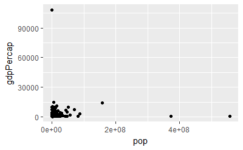

```r
library(gapminder)
library(dplyr)
library(ggplot2)
gapminder_1952 <- gapminder %>%
  filter(year == 1952)
# Change to put pop on the x-axis and gdpPercap on the y-axis
ggplot(gapminder_1952, aes(x = pop, y = gdpPercap)) +
  geom_point()
```

## Comparing population and life expectancy

In this exercise, you’ll use `ggplot2` to create a scatter plot from scratch, to compare each country’s population with its life expectancy in the year 1952.

INSTRUCTIONS

Create a scatter plot of `gapminder_1952` with population (`pop`) is on the x-axis and life expectancy (`lifeExp`) on the y-axis.

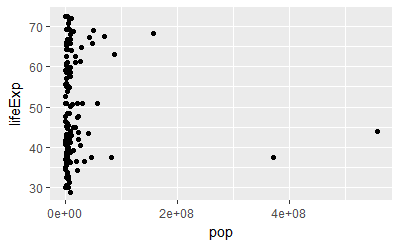

```r
library(gapminder)
library(dplyr)
library(ggplot2)
gapminder_1952 <- gapminder %>%
  filter(year == 1952)
# Create a scatter plot with pop on the x-axis and lifeExp on the y-axis
ggplot(gapminder_1952, aes(x = pop, y = lifeExp)) +
  geom_point()
```

## Putting the x-axis on a log scale

You previously created a scatter plot with population on the x-axis and life expectancy on the y-axis. Since population is spread over several orders of magnitude, with some countries having a much higher population than others, it’s a good idea to put the x-axis on a log scale.

INSTRUCTIONS

Change the existing scatter plot (code provided) to put the x-axis (representing population) on a log scale.

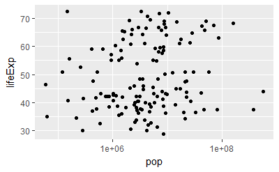

```r
library(gapminder)
library(dplyr)
library(ggplot2)
gapminder_1952 <- gapminder %>%
  filter(year == 1952)
# Change this plot to put the x-axis on a log scale
ggplot(gapminder_1952, aes(x = pop, y = lifeExp)) +
  geom_point() +
  scale_x_log10()
```

## Putting the x- and y- axes on a log scale

Suppose you want to create a scatter plot with population on the x-axis and GDP per capita on the y-axis. Both population and GDP per-capita are better represented with log scales, since they vary over many orders of magnitude.

INSTRUCTIONS

Create a scatter plot with population (`pop`) on the x-axis and GDP per capita (`gdpPercap`) on the y-axis. Put both the x- and y- axes on a log scale.

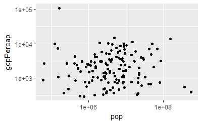

```r
library(gapminder)
library(dplyr)
library(ggplot2)
gapminder_1952 <- gapminder %>%
  filter(year == 1952)
# Scatter plot comparing pop and gdpPercap, with both axes on a log scale
ggplot(gapminder_1952, aes(x = pop, y = gdpPercap)) +
  geom_point() +
  scale_x_log10() +
  scale_y_log10()
```

## Adding color to a scatter plot

In this lesson you learned how to use the color aesthetic, which can be used to show which continent each point in a scatter plot represents.

INSTRUCTIONS

Create a scatter plot with population (`pop`) on the x-axis, life expectancy (`lifeExp`) on the y-axis, and with continent (`continent`) represented by the color of the points. Put the x-axis on a log scale.

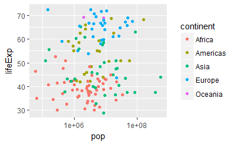

```r
library(gapminder)
library(dplyr)
library(ggplot2)
gapminder_1952 <- gapminder %>%
  filter(year == 1952)
# Scatter plot comparing pop and lifeExp, with color representing continent
ggplot(gapminder_1952, aes(x = pop, y = lifeExp, color = continent)) +
  geom_point() +
  scale_x_log10()
```

## Adding size and color to a plot

In the last exercise, you created a scatter plot communicating information about each country’s population, life expectancy, and continent. Now you’ll use the size of the points to communicate even more.

INSTRUCTIONS

Modify the scatter plot so that the size of the points represents each country’s GDP per capita (`gdpPercap`).

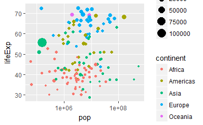

```r
library(gapminder)
library(dplyr)
library(ggplot2)
gapminder_1952 <- gapminder %>%
  filter(year == 1952)
# Add the size aesthetic to represent a country's gdpPercap
ggplot(gapminder_1952, aes(x = pop, y = lifeExp, color = continent,
                            size = gdpPercap)) +
  geom_point() +
  scale_x_log10()
```

## Creating a subgraph for each continent

You’ve learned to use faceting to divide a graph into subplots based on one of its variables, such as the continent.

INSTRUCTIONS

Create a scatter plot of `gapminder_1952` with the x-axis representing population (`pop`), the y-axis representing life expectancy (`lifeExp`), and faceted to have one subplot per continent (`continent`). Put the x-axis on a log scale.

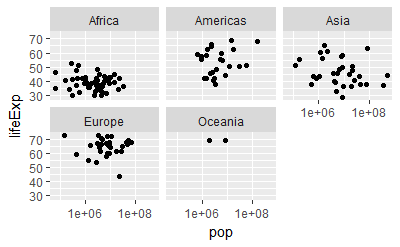

```r
library(gapminder)
library(dplyr)
library(ggplot2)
gapminder_1952 <- gapminder %>%
  filter(year == 1952)
# Scatter plot comparing pop and lifeExp, faceted by continent
ggplot(gapminder_1952, aes(x = pop, y = lifeExp)) +
  geom_point() +
  scale_x_log10()+
  facet_wrap(~ continent)
```

## Faceting by year

All of the graphs in this chapter have been visualizing statistics within one year. Now that you’re able to use faceting, however, you can create a graph showing all the country-level data from 1952 to 2007, to understand how global statistics have changed over time.

INSTRUCTIONS

Create a scatter plot of the gapminder data:

- Put GDP per capita (`gdpPercap`) on the x-axis and life expectancy (`lifeExp`) on the y-axis, with continent (`continent`) represented by color and population (`pop`) represented by size.
- Put the x-axis on a log scale
- Facet by the `year` variable

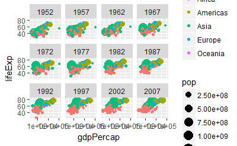

```r
library(gapminder)
library(dplyr)
library(ggplot2)
# Scatter plot comparing gdpPercap and lifeExp, with color representing continent
# and size representing population, faceted by year
ggplot(gapminder, aes(x = gdpPercap, y = lifeExp, color = continent,
                      size = pop)) +
      geom_point() +
      scale_x_log10() +
      facet_wrap(~ year)
```

# Chapter 3: Grouping and summarizing

# Chapter 4: Types of Visualization